# Credit card fraud detection using Machine Learning

Przemyslaw Zientala

# Problem

Credit card fraud is a major concern in the financial industry nowadays. It is estimated that £20M a day were lost due to fraudulent transactions in 2016 alone, totalling almost £770M annually (Financial Fraud Action UK; https://www.financialfraudaction.org.uk/fraudfacts16/assets/fraud_the_facts.pdf).

Analysing fraudulent transactions manually is unfeasible due to huge amounts of data and its complexity. However, given sufficiently informative features, one could expect it is possible to do using Machine Learning. This hypothesis will be explored in the project.

# Data description

The datasets contains transactions made by credit cards in September 2013 by european cardholders. This dataset presents transactions that occurred in two days, where we have 492 frauds out of 284,807 transactions. The dataset is highly unbalanced, the positive class (frauds) account for 0.172% of all transactions.

It contains only numerical input variables which are the result of a PCA transformation. Unfortunately, due to confidentiality issues, we cannot provide the original features and more background information about the data. Features V1, V2, … V28 are the principal components obtained with PCA, the only features which have not been transformed with PCA are ‘Time’ and ‘Amount’. Feature ‘Time’ contains the seconds elapsed between each transaction and the first transaction in the dataset. The feature ‘Amount’ is the transaction Amount, this feature can be used for example-dependant cost-senstive learning. Feature ‘Class’ is the response variable and it takes value 1 in case of fraud and 0 otherwise.

Given the class imbalance ratio, we recommend measuring the accuracy using the Area Under the Precision-Recall Curve (AUPRC). Confusion matrix accuracy is not meaningful for unbalanced classification.

The dataset has been collected and analysed during a research collaboration of Worldline and the Machine Learning Group (http://mlg.ulb.ac.be) of ULB (Université Libre de Bruxelles) on big data mining and fraud detection. More details on current and past projects on related topics are available on http://mlg.ulb.ac.be/BruFence and http://mlg.ulb.ac.be/ARTML

Please cite: Andrea Dal Pozzolo, Olivier Caelen, Reid A. Johnson and Gianluca Bontempi. Calibrating Probability with Undersampling for Unbalanced Classification. In Symposium on Computational Intelligence and Data Mining (CIDM), IEEE, 2015

# Exploratory data analysis and data cleaning

## Exploratory analysis

```r
# Load libraries
library(data.table)
library(ggplot2)
library(plyr)
library(dplyr)
library(corrplot)
library(pROC)
library(glmnet)
library(caret)
library(Rtsne)
library(xgboost)
library(doMC)
```

```r
# Load data
data <- fread("data/creditcard.csv")
```

```
Read 63.2% of 284807 rows
Read 284807 rows and 31 (of 31) columns from 0.140 GB file in 00:00:03
```

```r
head(data)
```

| Time | V1 | V2 | V3 | V4 | V5 | V6 | V7 | V8 | V9 | V10 | V11 | V12 | V13 | V14 | V15 | V16 | V17 | V18 | V19 | V20 | V21 | V22 | V23 | V24 | V25 | V26 | V27 | V28 | Amount | … |
| --- | --- | --- | --- | --- | --- | --- | --- | --- | --- | --- | --- | --- | --- | --- | --- | --- | --- | --- | --- | --- | --- | --- | --- | --- | --- | --- | --- | --- | --- | --- |
| 0 | -1.3598071 | -0.07278117 | 2.5363467 | 1.3781552 | -0.33832077 | 0.46238778 | 0.23959855 | 0.09869790 | 0.3637870 | 0.09079417 | -0.5515995 | -0.61780086 | -0.9913898 | -0.3111694 | 1.4681770 | -0.4704005 | 0.20797124 | 0.02579058 | 0.40399296 | 0.25141210 | -0.018306778 | 0.277837576 | -0.11047391 | 0.06692807 | 0.1285394 | -0.1891148 | 0.133558377 | -0.02105305 | 149.62 | … |
| 0 | 1.1918571 | 0.26615071 | 0.1664801 | 0.4481541 | 0.06001765 | -0.08236081 | -0.07880298 | 0.08510165 | -0.2554251 | -0.16697441 | 1.6127267 | 1.06523531 | 0.4890950 | -0.1437723 | 0.6355581 | 0.4639170 | -0.11480466 | -0.18336127 | -0.14578304 | -0.06908314 | -0.225775248 | -0.638671953 | 0.10128802 | -0.33984648 | 0.1671704 | 0.1258945 | -0.008983099 | 0.01472417 | 2.69 | … |
| 1 | -1.3583541 | -1.34016307 | 1.7732093 | 0.3797796 | -0.50319813 | 1.80049938 | 0.79146096 | 0.24767579 | -1.5146543 | 0.20764287 | 0.6245015 | 0.06608369 | 0.7172927 | -0.1659459 | 2.3458649 | -2.8900832 | 1.10996938 | -0.12135931 | -2.26185710 | 0.52497973 | 0.247998153 | 0.771679402 | 0.90941226 | -0.68928096 | -0.3276418 | -0.1390966 | -0.055352794 | -0.05975184 | 378.66 | … |
| 1 | -0.9662717 | -0.18522601 | 1.7929933 | -0.8632913 | -0.01030888 | 1.24720317 | 0.23760894 | 0.37743587 | -1.3870241 | -0.05495192 | -0.2264873 | 0.17822823 | 0.5077569 | -0.2879237 | -0.6314181 | -1.0596472 | -0.68409279 | 1.96577500 | -1.23262197 | -0.20803778 | -0.108300452 | 0.005273597 | -0.19032052 | -1.17557533 | 0.6473760 | -0.2219288 | 0.062722849 | 0.06145763 | 123.50 | … |
| 2 | -1.1582331 | 0.87773675 | 1.5487178 | 0.4030339 | -0.40719338 | 0.09592146 | 0.59294075 | -0.27053268 | 0.8177393 | 0.75307443 | -0.8228429 | 0.53819555 | 1.3458516 | -1.1196698 | 0.1751211 | -0.4514492 | -0.23703324 | -0.03819479 | 0.80348692 | 0.40854236 | -0.009430697 | 0.798278495 | -0.13745808 | 0.14126698 | -0.2060096 | 0.5022922 | 0.219422230 | 0.21515315 | 69.99 | … |
| 2 | -0.4259659 | 0.96052304 | 1.1411093 | -0.1682521 | 0.42098688 | -0.02972755 | 0.47620095 | 0.26031433 | -0.5686714 | -0.37140720 | 1.3412620 | 0.35989384 | -0.3580907 | -0.1371337 | 0.5176168 | 0.4017259 | -0.05813282 | 0.06865315 | -0.03319379 | 0.08496767 | -0.208253515 | -0.559824796 | -0.02639767 | -0.37142658 | -0.2327938 | 0.1059148 | 0.253844225 | 0.08108026 | 3.67 | … |

All the features, apart from “time” and “amount” are anonymised. Let’s see whether there is any missing data.

```r
apply(data, 2, function(x) sum(is.na(x)))
```

```
  Time     V1     V2     V3     V4     V5     V6     V7     V8     V9    V10    V11    V12    V13    V14    V15    V16    V17    V18
     0      0      0      0      0      0      0      0      0      0      0      0      0      0      0      0      0      0      0
   V19    V20    V21    V22    V23    V24    V25    V26    V27    V28 Amount  Class
     0      0      0      0      0      0      0      0      0      0      0      0
```

Good news! There are no NA values in the data.

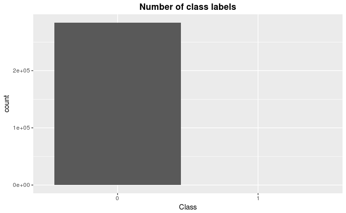

```r
common_theme <- theme(plot.title = element_text(hjust = 0.5, face = "bold"))
p <- ggplot(data, aes(x = Class)) + geom_bar() + ggtitle("Number of class labels") + common_theme
print(p)
```

Clearly, the dataset is extremely unbalanced. Even a “null” classifier which always predicts class=0 would obtain over 99% accuracy on this task. This demonstrates that a simple measure of mean accuracy should not be used due to insensitivity to false negatives.

**The most appropriate measures to use on this task would be:**

1. Precision
2. Recall
3. F-1 score (harmonic mean of precision and recall)
4. AUC (area under precision-recall curve)

**Additionally, we can transform the data itself in numerous ways:**

1. Oversampling
2. Undersampling
3. SMOTE (Synthetic Minority Over-sampling Technique)

```r
summary(data)
```

```
      Time              V1                  V2                  V3                 V4                 V5
 Min.   :     0   Min.   :-56.40751   Min.   :-72.71573   Min.   :-48.3256   Min.   :-5.68317   Min.   :-113.74331
 1st Qu.: 54202   1st Qu.: -0.92037   1st Qu.: -0.59855   1st Qu.: -0.8904   1st Qu.:-0.84864   1st Qu.:  -0.69160
 Median : 84692   Median :  0.01811   Median :  0.06549   Median :  0.1799   Median :-0.01985   Median :  -0.05434
 Mean   : 94814   Mean   :  0.00000   Mean   :  0.00000   Mean   :  0.0000   Mean   : 0.00000   Mean   :   0.00000
 3rd Qu.:139320   3rd Qu.:  1.31564   3rd Qu.:  0.80372   3rd Qu.:  1.0272   3rd Qu.: 0.74334   3rd Qu.:   0.61193
 Max.   :172792   Max.   :  2.45493   Max.   : 22.05773   Max.   :  9.3826   Max.   :16.87534   Max.   :  34.80167
       V6                 V7                 V8                  V9                 V10                 V11
 Min.   :-26.1605   Min.   :-43.5572   Min.   :-73.21672   Min.   :-13.43407   Min.   :-24.58826   Min.   :-4.79747
 1st Qu.: -0.7683   1st Qu.: -0.5541   1st Qu.: -0.20863   1st Qu.: -0.64310   1st Qu.: -0.53543   1st Qu.:-0.76249
 Median : -0.2742   Median :  0.0401   Median :  0.02236   Median : -0.05143   Median : -0.09292   Median :-0.03276
 Mean   :  0.0000   Mean   :  0.0000   Mean   :  0.00000   Mean   :  0.00000   Mean   :  0.00000   Mean   : 0.00000
 3rd Qu.:  0.3986   3rd Qu.:  0.5704   3rd Qu.:  0.32735   3rd Qu.:  0.59714   3rd Qu.:  0.45392   3rd Qu.: 0.73959
 Max.   : 73.3016   Max.   :120.5895   Max.   : 20.00721   Max.   : 15.59500   Max.   : 23.74514   Max.   :12.01891
      V12                V13                V14                V15                V16                 V17
 Min.   :-18.6837   Min.   :-5.79188   Min.   :-19.2143   Min.   :-4.49894   Min.   :-14.12985   Min.   :-25.16280
 1st Qu.: -0.4056   1st Qu.:-0.64854   1st Qu.: -0.4256   1st Qu.:-0.58288   1st Qu.: -0.46804   1st Qu.: -0.48375
 Median :  0.1400   Median :-0.01357   Median :  0.0506   Median : 0.04807   Median :  0.06641   Median : -0.06568
 Mean   :  0.0000   Mean   : 0.00000   Mean   :  0.0000   Mean   : 0.00000   Mean   :  0.00000   Mean   :  0.00000
 3rd Qu.:  0.6182   3rd Qu.: 0.66251   3rd Qu.:  0.4931   3rd Qu.: 0.64882   3rd Qu.:  0.52330   3rd Qu.:  0.39968
 Max.   :  7.8484   Max.   : 7.12688   Max.   : 10.5268   Max.   : 8.87774   Max.   : 17.31511   Max.   :  9.25353
      V18                 V19                 V20                 V21                 V22                  V23
 Min.   :-9.498746   Min.   :-7.213527   Min.   :-54.49772   Min.   :-34.83038   Min.   :-10.933144   Min.   :-44.80774
 1st Qu.:-0.498850   1st Qu.:-0.456299   1st Qu.: -0.21172   1st Qu.: -0.22839   1st Qu.: -0.542350   1st Qu.: -0.16185
 Median :-0.003636   Median : 0.003735   Median : -0.06248   Median : -0.02945   Median :  0.006782   Median : -0.01119
 Mean   : 0.000000   Mean   : 0.000000   Mean   :  0.00000   Mean   :  0.00000   Mean   :  0.000000   Mean   :  0.00000
 3rd Qu.: 0.500807   3rd Qu.: 0.458949   3rd Qu.:  0.13304   3rd Qu.:  0.18638   3rd Qu.:  0.528554   3rd Qu.:  0.14764
 Max.   : 5.041069   Max.   : 5.591971   Max.   : 39.42090   Max.   : 27.20284   Max.   : 10.503090   Max.   : 22.52841
      V24                V25                 V26                V27                  V28                Amount
 Min.   :-2.83663   Min.   :-10.29540   Min.   :-2.60455   Min.   :-22.565679   Min.   :-15.43008   Min.   :    0.00
 1st Qu.:-0.35459   1st Qu.: -0.31715   1st Qu.:-0.32698   1st Qu.: -0.070840   1st Qu.: -0.05296   1st Qu.:    5.60
 Median : 0.04098   Median :  0.01659   Median :-0.05214   Median :  0.001342   Median :  0.01124   Median :   22.00
 Mean   : 0.00000   Mean   :  0.00000   Mean   : 0.00000   Mean   :  0.000000   Mean   :  0.00000   Mean   :   88.35
 3rd Qu.: 0.43953   3rd Qu.:  0.35072   3rd Qu.: 0.24095   3rd Qu.:  0.091045   3rd Qu.:  0.07828   3rd Qu.:   77.17
 Max.   : 4.58455   Max.   :  7.51959   Max.   : 3.51735   Max.   : 31.612198   Max.   : 33.84781   Max.   :25691.16
    Class
 Length:284807
 Class :character
 Mode  :character
```

All the anonymised features seem to have been be normalised with mean 0. We will apply that transformation to the “Amount” column later on to facilitate training ML models.

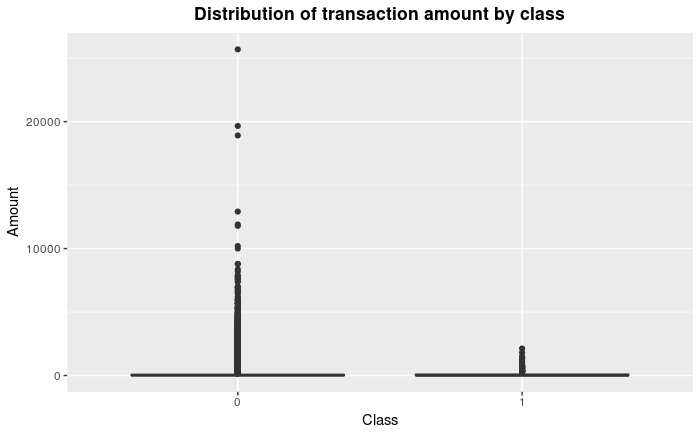

```r
p <- ggplot(data, aes(x = Class, y = Amount)) + geom_boxplot() + ggtitle("Distribution of transaction amount by class") + common_theme
print(p)
```

There is clearly a lot more variability in the transaction values for non-fraudulent transactions. To get a fuller picture, let’s compute the mean and median values for each class.

```r
data %>% group_by(Class) %>% summarise(mean(Amount), median(Amount))
```

| Class | mean(Amount) | median(Amount) |
| --- | --- | --- |
| 0 | 88.29102 | 22.00 |
| 1 | 122.21132 | 9.25 |

Since almost all the features are anonymised, let’s see whether there are any correlations with the “Class” feature.

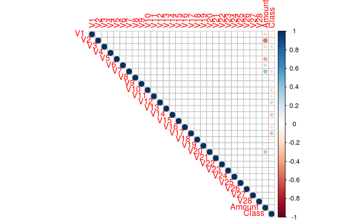

```r
data$Class <- as.numeric(data$Class)
corr_plot <- corrplot(cor(data[,-c("Time")]), method = "circle", type = "upper")
```

There are a couple interesting correlations with the “Amount” and “Class” features. We will focus on these variables later on during feature selection for the model.

Let’s apply that transformation to the “Amount” column too.

```r
normalize <- function(x)
      return((x - mean(x, na.rm = TRUE))/sd(x, na.rm = TRUE))
data$Amount <- normalize(data$Amount)
```

### Visualization of transactions using t-SNE

To try to understand the data better, we will try visualizing the data using [t-Distributed Stochastic Neighbour Embedding](https://lvdmaaten.github.io/tsne/), a technique to reduce dimensionality using Barnes-Hut approximations.

To train the model, perplexity was set to 20. This was based on experimentation and there is no “best” value to use. However, the author of the algorithm suggests using a value of 5-50.

The visualisation should give us a hint as to whether there exist any “discoverable” patterns in the data which the model could learn. If there is no obvious structure in the data, it is more likely that the model will perform poorly.

```r
# Use 10% of data to compute t-SNE
tsne_subset <- 1:as.integer(0.1*nrow(data))
tsne <- Rtsne(data[tsne_subset,-c("Class", "Time")], perplexity = 20, theta = 0.5, pca = F, verbose = T, max_iter = 500, check_duplicates = F)
```

```
Read the 28480 x 29 data matrix successfully!
Using no_dims = 2, perplexity = 20.000000, and theta = 0.500000
Computing input similarities...
Normalizing input...
Building tree...
 - point 0 of 28480
 - point 10000 of 28480
 - point 20000 of 28480
Done in 27.76 seconds (sparsity = 0.003025)!
Learning embedding...
Iteration 50: error is 114.699124 (50 iterations in 30.08 seconds)
Iteration 100: error is 114.619733 (50 iterations in 31.03 seconds)
Iteration 150: error is 97.857498 (50 iterations in 27.61 seconds)
Iteration 200: error is 91.989974 (50 iterations in 27.50 seconds)
Iteration 250: error is 89.244735 (50 iterations in 30.15 seconds)
Iteration 300: error is 4.028579 (50 iterations in 29.04 seconds)
Iteration 350: error is 3.589559 (50 iterations in 27.68 seconds)
Iteration 400: error is 3.291539 (50 iterations in 33.09 seconds)
Iteration 450: error is 3.068981 (50 iterations in 29.38 seconds)
Iteration 500: error is 2.893443 (50 iterations in 27.41 seconds)
Fitting performed in 292.97 seconds.
```

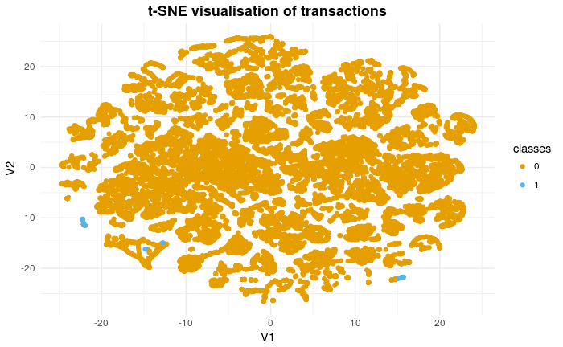

```r
classes <- as.factor(data$Class[tsne_subset])
tsne_mat <- as.data.frame(tsne$Y)
ggplot(tsne_mat, aes(x = V1, y = V2)) + geom_point(aes(color = classes)) + theme_minimal() + common_theme + ggtitle("t-SNE visualisation of transactions") + scale_color_manual(values = c("#E69F00", "#56B4E9"))
```

Luckily, there is a rather clear distinction between legitimate and fraudulent transactions, which seem to lie at the edge of the “blob” of data. This is encouraging news, let’s see whether we can make our models detect fraudulent transactions!

# Model development

To avoid developing a “naive” model, we should make sure the classes are roughly balanced. Therefore, we will use a resampling (and, more precisely, oversampling) scheme called SMOTE. It works roughly as follows:

1. The algorithm selects 2 or more similar instances of data
2. It then perturbs each instance one feature at a time by a random amount. This amount is within the distance to the neighbouring examples.

**SMOTE has been shown to perform better classification performance in the ROC space than either over- or undersampling** *(From Nitesh V. Chawla, Kevin W. Bowyer, Lawrence O. Hall and W. Philip Kegelmeyer’s “SMOTE: Synthetic Minority Over-sampling Technique” (Journal of Artificial Intelligence Research, 2002, Vol. 16, pp. 321–357))*. **Since ROC is the measure we are going to optimize for, we will use SMOTE to resample the data.**

**It is typically a good idea to start out with a simple model and move on to more complex ones to have a rough idea of what “good” performance means on our data.** Moroever, it is important to consider the tradeoff between model accuracy and model complexity (which is inherently tied to computational cost). It might be the case that having a simple model with short inference times which achieves an accuracy of 85% is sufficient for a given task, as opposed to having a, say, 10-layer neural network which trains for 2 days on a GPU cluster and is 90% accurate.

Therefore, we will start out with logistic regression.

### Logistic regression

Logistic regression is a simple regression model whose output is a score between 0 and 1. This is achieved by using the logistic function:

$$g(z) = \frac{1}{1 + exp(-z)}$$
Where:
$$z = \beta^T x$$

The model can be fitted using gradient descent on the parameter vector beta. Equipped with some basic information, let’s fit the model and see how it performs!

```r
log_mod <- glm(Class ~ ., family = "binomial", data = X_train)
summary(log_mod)
```

```
Call:
glm(formula = Class ~ ., family = "binomial", data = X_train)

Deviance Residuals:
    Min       1Q   Median       3Q      Max
-4.8020  -0.0298  -0.0194  -0.0123   4.6025

Coefficients:
              Estimate Std. Error z value Pr(>|z|)
(Intercept) -8.274e+00  2.702e-01 -30.618  < 2e-16 ***
Time        -4.086e-06  2.485e-06  -1.645 0.100068
V1           9.452e-02  4.686e-02   2.017 0.043683 *
V2           1.804e-02  6.488e-02   0.278 0.780999
V3          -2.502e-02  5.889e-02  -0.425 0.671000
V4           6.845e-01  8.277e-02   8.271  < 2e-16 ***
V5           1.380e-01  7.473e-02   1.846 0.064821 .
V6          -1.070e-01  8.162e-02  -1.310 0.190035
V7          -9.144e-02  7.410e-02  -1.234 0.217190
V8          -1.699e-01  3.336e-02  -5.095 3.50e-07 ***
V9          -2.817e-01  1.249e-01  -2.255 0.024104 *
V10         -8.052e-01  1.054e-01  -7.640 2.16e-14 ***
V11         -1.338e-01  9.018e-02  -1.483 0.137993
V12          1.414e-01  1.013e-01   1.395 0.162906
V13         -3.470e-01  9.289e-02  -3.735 0.000188 ***
V14         -5.972e-01  7.105e-02  -8.406  < 2e-16 ***
V15         -6.793e-02  9.646e-02  -0.704 0.481283
V16         -2.057e-01  1.413e-01  -1.456 0.145330
V17         -4.874e-02  7.854e-02  -0.621 0.534847
V18          2.853e-02  1.449e-01   0.197 0.843865
V19          1.833e-01  1.087e-01   1.687 0.091588 .
V20         -4.249e-01  9.021e-02  -4.710 2.47e-06 ***
V21          3.871e-01  6.715e-02   5.765 8.18e-09 ***
V22          6.555e-01  1.503e-01   4.361 1.29e-05 ***
V23         -1.374e-01  6.509e-02  -2.110 0.034830 *
V24          9.196e-02  1.620e-01   0.568 0.570166
V25          2.004e-02  1.447e-01   0.138 0.889860
V26         -1.439e-03  2.124e-01  -0.007 0.994596
V27         -8.038e-01  1.336e-01  -6.018 1.77e-09 ***
V28         -2.324e-01  9.447e-02  -2.460 0.013883 *
Amount       2.378e-01  1.050e-01   2.264 0.023597 *
---
Signif. codes:  0 ‘***’ 0.001 ‘**’ 0.01 ‘*’ 0.05 ‘.’ 0.1 ‘ ’ 1

(Dispersion parameter for binomial family taken to be 1)

    Null deviance: 5875.3  on 227845  degrees of freedom
Residual deviance: 1816.7  on 227815  degrees of freedom
AIC: 1878.7

Number of Fisher Scoring iterations: 12
```

```r
# Use a threshold of 0.5 to transform predictions to binary
conf_mat <- confusionMatrix(y_test, as.numeric(predict(log_mod, X_test, type = "response") > 0.5))
print(conf_mat)
```

```
Confusion Matrix and Statistics

          Reference
Prediction     0     1
         0 56861     8
         1    34    58

               Accuracy : 0.9993
                 95% CI : (0.999, 0.9995)
    No Information Rate : 0.9988
    P-Value [Acc > NIR] : 0.0010494

                  Kappa : 0.7338
 Mcnemar's Test P-Value : 0.0001145

            Sensitivity : 0.9994
            Specificity : 0.8788
         Pos Pred Value : 0.9999
         Neg Pred Value : 0.6304
             Prevalence : 0.9988
         Detection Rate : 0.9982
   Detection Prevalence : 0.9984
      Balanced Accuracy : 0.9391

       'Positive' Class : 0
```

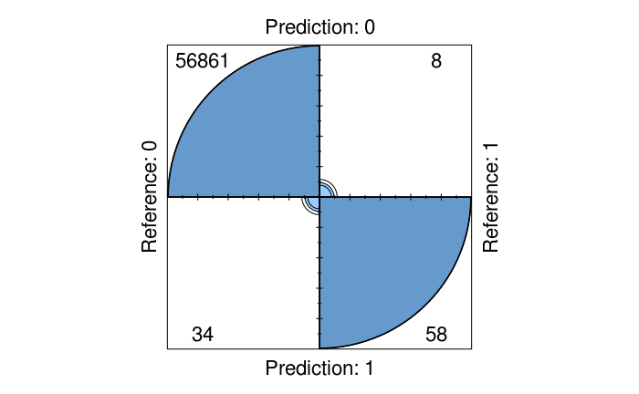

```r
fourfoldplot(conf_mat$table)
```

```r
conf_mat2 <- confusionMatrix(y_test, as.numeric(predict(log_mod, X_test, type = "response") > 0.999))
print(conf_mat2)
```

```
Confusion Matrix and Statistics

          Reference
Prediction     0     1
         0 56866     3
         1    67    25

               Accuracy : 0.9988
                 95% CI : (0.9984, 0.999)
    No Information Rate : 0.9995
    P-Value [Acc > NIR] : 1

                  Kappa : 0.4162
 Mcnemar's Test P-Value : 5.076e-14

            Sensitivity : 0.9988
            Specificity : 0.8929
         Pos Pred Value : 0.9999
         Neg Pred Value : 0.2717
             Prevalence : 0.9995
         Detection Rate : 0.9983
   Detection Prevalence : 0.9984
      Balanced Accuracy : 0.9458

       'Positive' Class : 0
```

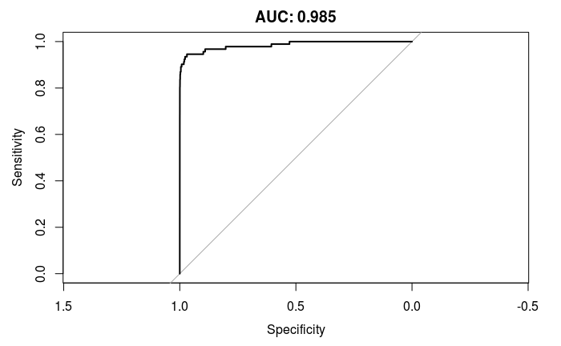

```r
roc_logmod <- roc(y_test, as.numeric(predict(log_mod, X_test, type = "response")))
plot(roc_logmod, main = paste0("AUC: ", round(pROC::auc(roc_logmod), 3)))
```

Let’s now move on to Random Forest and see whether we can improve any further.

### Random Forest

```r
# Train a Random Forest classifier, maximising recall (sensitivity)
X_train_rf <- X_train
X_train_rf$Class <- as.factor(X_train_rf$Class)
levels(X_train_rf$Class) <- make.names(c(0, 1))
model_rf_smote <- train(Class ~ ., data = X_train_rf, method = "rf", trControl = ctrl, verbose = T, metric = "ROC")
```

The code above uses SMOTE to resample the data, performs 10-fold CV and trains a Random Forest classifier using ROC as metric to maximize. Let’s look at its performance!

```r
model_rf_smote
```

```
Random Forest

227846 samples
    30 predictors
     2 classes: 'X0', 'X1'

No pre-processing
Resampling: Cross-Validated (10 fold)
Summary of sample sizes: 205062, 205062, 205061, 205062, 205062, 205061, ...
Addtional sampling using SMOTE

Resampling results across tuning parameters:

  mtry  ROC        Sens       Spec
   2    0.9796401  0.9954671  0.8775
  16    0.9825342  0.9901339  0.8850
  30    0.9814775  0.9850074  0.8850

ROC was used to select the optimal model using  the largest value.
The final value used for the model was mtry = 16.
```

**It is important to note that SMOTE resampling was done only on the training data**. The reason for that is if we performed it on the whole dataset and then made the split, SMOTE would *bleed* some information into the testing set, thereby biasing the results in an optimistic way.

The results on the training set look very promising. Let’s see how the model performs on the unseen test set.

```r
preds <- predict(model_rf_smote, X_test, type = "prob")
conf_mat_rf <- confusionMatrix(as.numeric(preds$X1 > 0.5), y_test)
print(conf_mat_rf)
```

```
Confusion Matrix and Statistics

          Reference
Prediction     0     1
         0 56443     8
         1   426    84

               Accuracy : 0.9924
                 95% CI : (0.9916, 0.9931)
    No Information Rate : 0.9984
    P-Value [Acc > NIR] : 1

                  Kappa : 0.2771
 Mcnemar's Test P-Value : <2e-16

            Sensitivity : 0.9925
            Specificity : 0.9130
         Pos Pred Value : 0.9999
         Neg Pred Value : 0.1647
             Prevalence : 0.9984
         Detection Rate : 0.9909
   Detection Prevalence : 0.9910
      Balanced Accuracy : 0.9528

       'Positive' Class : 0
```

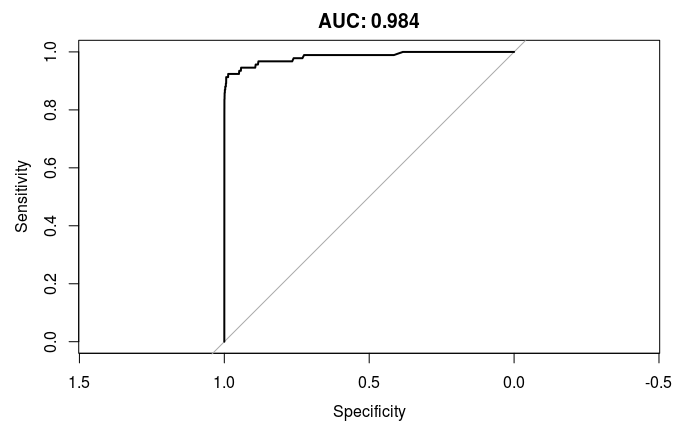

```r
roc_data <- roc(y_test, predict(model_rf_smote, X_test, type = "prob")$X1)
plot(roc_data, main = paste0("AUC: ", round(pROC::auc(roc_data), 3)))
```

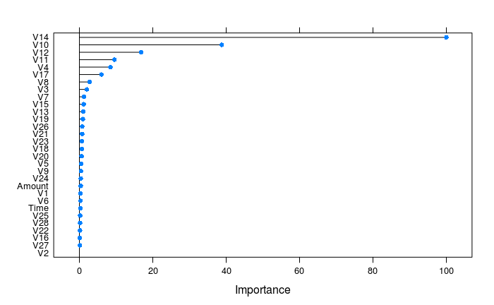

```r
plot(varImp(model_rf_smote))
```

It is interesting to compare variable importances of the RF model with the variables identified earlier as correlated with the “Class” variable. The top 3 most important variables in the RF model were also the ones which were most correlated with the “Class” variable. Especially for large datasets, this means we could save disk space and computation time by only training the model on the most correlated/important variables, sacrificing a bit of model accuracy.

### XGBoost

Lastly, we can also try *XGBoost*, which is based on Gradient Boosted Trees and is a more powerful model compared to both Logistic Regression and Random Forest.

```r
dtrain_X <- xgb.DMatrix(data = as.matrix(X_train[,-c("Class")]), label = as.numeric(X_train$Class))
dtest_X <- xgb.DMatrix(data = as.matrix(X_test[,-c("Class")]), label = as.numeric(X_test$Class))
xgb <- xgboost(data = dtrain_X, nrounds = 100, gamma = 0.1, max_depth = 10, objective = "binary:logistic", nthread = 7)
preds_xgb <- predict(xgb, dtest_X)
confusionMatrix(as.numeric(preds_xgb > 0.5), y_test)
```

```
Confusion Matrix and Statistics

          Reference
Prediction     0     1
         0 56863    17
         1     6    75

               Accuracy : 0.9996
                 95% CI : (0.9994, 0.9997)
    No Information Rate : 0.9984
    P-Value [Acc > NIR] : < 2e-16

                  Kappa : 0.8669
 Mcnemar's Test P-Value : 0.03706

            Sensitivity : 0.9999
            Specificity : 0.8152
         Pos Pred Value : 0.9997
         Neg Pred Value : 0.9259
             Prevalence : 0.9984
         Detection Rate : 0.9983
   Detection Prevalence : 0.9986
      Balanced Accuracy : 0.9076

       'Positive' Class : 0
```

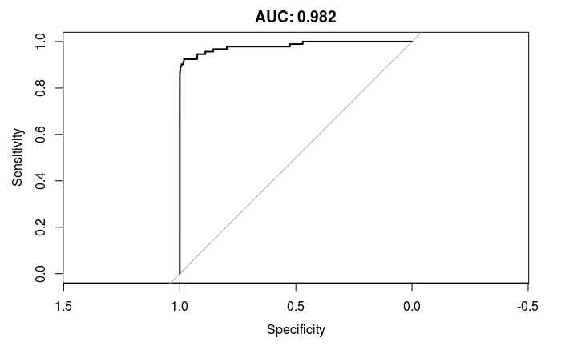

```r
roc_xgb <- roc(y_test, preds_xgb)
plot(roc_xgb, main = paste0("AUC: ", round(pROC::auc(roc_xgb), 3)))
```

# Summary